*Note, if nycflights13 in not installed in your system, RStudio might prompt you to install it, or simply run `install.packages("nycflights13")` in the console.*

# 1. Data Structure Summary & Initial Exploration

## 1.1 Subset the Data

**Write code to create the subset `jan_feb_flights` below:**

```r
jan_feb_flights <- flights %>%
  filter(month %in% c(1, 2))
jan_feb_flights
```

```
## # A tibble: 51,955 × 19
##     year month   day dep_time sched_dep_time dep_delay arr_time sched_arr_time
##    <int> <int> <int>    <int>          <int>     <dbl>    <int>          <int>
##  1  2013     1     1      517            515         2      830            819
##  2  2013     1     1      533            529         4      850            830
##  3  2013     1     1      542            540         2      923            850
##  4  2013     1     1      544            545        -1     1004           1022
##  5  2013     1     1      554            600        -6      812            837
##  6  2013     1     1      554            558        -4      740            728
##  7  2013     1     1      555            600        -5      913            854
##  8  2013     1     1      557            600        -3      709            723
##  9  2013     1     1      557            600        -3      838            846
## 10  2013     1     1      558            600        -2      753            745
## # ℹ 51,945 more rows
## # ℹ 11 more variables: arr_delay <dbl>, carrier <chr>, flight <int>,
## #   tailnum <chr>, origin <chr>, dest <chr>, air_time <dbl>, distance <dbl>,
## #   hour <dbl>, minute <dbl>, time_hour <dttm>
```

## 1.2 Column Overview

Explore the columns in `jan_feb_flights`. Which are numeric, which are categorical/text/factor?  
Are there missing values?

```r
# explore the types of the columns in jan_feb_flights
```

```r
# which columns are integer
jan_feb_flights%>%
  select(where(is.integer))
```

```
## # A tibble: 51,955 × 8
##     year month   day dep_time sched_dep_time arr_time sched_arr_time flight
##    <int> <int> <int>    <int>          <int>    <int>          <int>  <int>
##  1  2013     1     1      517            515      830            819   1545
##  2  2013     1     1      533            529      850            830   1714
##  3  2013     1     1      542            540      923            850   1141
##  4  2013     1     1      544            545     1004           1022    725
##  5  2013     1     1      554            600      812            837    461
##  6  2013     1     1      554            558      740            728   1696
##  7  2013     1     1      555            600      913            854    507
##  8  2013     1     1      557            600      709            723   5708
##  9  2013     1     1      557            600      838            846     79
## 10  2013     1     1      558            600      753            745    301
## # ℹ 51,945 more rows
```

```r
# which columns are double
jan_feb_flights%>%
  select(where(is.double))
```

```
## # A tibble: 51,955 × 7
##    dep_delay arr_delay air_time distance  hour minute time_hour
##        <dbl>     <dbl>    <dbl>    <dbl> <dbl>  <dbl> <dttm>
##  1         2        11      227     1400     5     15 2013-01-01 05:00:00
##  2         4        20      227     1416     5     29 2013-01-01 05:00:00
##  3         2        33      160     1089     5     40 2013-01-01 05:00:00
##  4        -1       -18      183     1576     5     45 2013-01-01 05:00:00
##  5        -6       -25      116      762     6      0 2013-01-01 06:00:00
##  6        -4        12      150      719     5     58 2013-01-01 05:00:00
##  7        -5        19      158     1065     6      0 2013-01-01 06:00:00
##  8        -3       -14       53      229     6      0 2013-01-01 06:00:00
##  9        -3        -8      140      944     6      0 2013-01-01 06:00:00
## 10        -2         8      138      733     6      0 2013-01-01 06:00:00
## # ℹ 51,945 more rows
```

```r
# which columns are character
jan_feb_flights%>%
  select(where(is.character))
```

```
## # A tibble: 51,955 × 4
##    carrier tailnum origin dest
##    <chr>   <chr>   <chr>  <chr>
##  1 UA      N14228  EWR    IAH
##  2 UA      N24211  LGA    IAH
##  3 AA      N619AA  JFK    MIA
##  4 B6      N804JB  JFK    BQN
##  5 DL      N668DN  LGA    ATL
##  6 UA      N39463  EWR    ORD
##  7 B6      N516JB  EWR    FLL
##  8 EV      N829AS  LGA    IAD
##  9 B6      N593JB  JFK    MCO
## 10 AA      N3ALAA  LGA    ORD
## # ℹ 51,945 more rows
```

```r
# which columns contain NA's

jan_feb_flights %>%
  summarise(across(everything(), ~sum(is.na(.))))
```

```
## # A tibble: 1 × 19
##    year month   day dep_time sched_dep_time dep_delay arr_time sched_arr_time
##   <int> <int> <int>    <int>          <int>     <int>    <int>          <int>
## 1     0     0     0     1782              0      1782     1827              0
## # ℹ 11 more variables: arr_delay <int>, carrier <int>, flight <int>,
## #   tailnum <int>, origin <int>, dest <int>, air_time <int>, distance <int>,
## #   hour <int>, minute <int>, time_hour <int>
```

**Summary:**

## 1.3 Reflection

Did the GenAI explanation (if used) help you? Which language model you explored? What was clear or unclear? Did it make any errors or skip anything important? Did you fact-check? Did you need to provide follow-up prompts or clarifications, or was the first response sufficient?

# 2. Delays & Weather

**Goal:** Analyze relationship between average departure delay and wind gust speed.

## 2.1 Code

```r
## REMEMBER TO SET eval=TRUE

# join the datasets
jan_feb_flights <- jan_feb_flights %>%

  left_join(weather, by = c("origin", "year", "month", "day", "hour"))
```

```r
# is there a difference in wind speed when wind_gust is missing vs not missing?
jan_feb_flights%>%
  filter(is.na(wind_gust))%>%
summarise(avg_wind_speed = mean(wind_speed, na.rm = TRUE),
            sd_wind_speed = sd(wind_speed, na.rm = TRUE),
  n())
```

```
## # A tibble: 1 × 3
##   avg_wind_speed sd_wind_speed `n()`
##            <dbl>         <dbl> <int>
## 1           9.18          4.47 37043
```

```r
jan_feb_flights %>%
  filter(!is.na(wind_gust)) %>%
  summarise(avg_wind_speed = mean(wind_speed, na.rm = TRUE),
            sd_wind_speed = sd(wind_speed, na.rm = TRUE),
            n())
```

```
## # A tibble: 1 × 3
##   avg_wind_speed sd_wind_speed `n()`
##            <dbl>         <dbl> <int>
## 1           19.2          5.73 14912
```

```r
jan_feb_flights %>%
  mutate(gust_present = !is.na(wind_gust)) %>%
  group_by(gust_present) %>%
  summarise(
    n = n(),
    mean = mean(wind_speed),
    median= median(wind_speed)
  )
```

```
## # A tibble: 2 × 4
##   gust_present     n  mean median
##   <lgl>        <int> <dbl>  <dbl>
## 1 FALSE        37043  NA     NA
## 2 TRUE         14912  19.2   18.4
```

Describe the difference in wind speed when wind_gust is missing vs not missing:

```r
## REMEMBER TO SET eval=TRUE

# create a new variable, gust_present
jan_feb_flights <- jan_feb_flights %>%
  mutate(gust_present = ifelse(!is.na(wind_gust), TRUE, FALSE))
jan_feb_flights
```

```
## # A tibble: 51,955 × 30
##     year month   day dep_time sched_dep_time dep_delay arr_time sched_arr_time
##    <int> <int> <int>    <int>          <int>     <dbl>    <int>          <int>
##  1  2013     1     1      517            515         2      830            819
##  2  2013     1     1      533            529         4      850            830
##  3  2013     1     1      542            540         2      923            850
##  4  2013     1     1      544            545        -1     1004           1022
##  5  2013     1     1      554            600        -6      812            837
##  6  2013     1     1      554            558        -4      740            728
##  7  2013     1     1      555            600        -5      913            854
##  8  2013     1     1      557            600        -3      709            723
##  9  2013     1     1      557            600        -3      838            846
## 10  2013     1     1      558            600        -2      753            745
## # ℹ 51,945 more rows
## # ℹ 22 more variables: arr_delay <dbl>, carrier <chr>, flight <int>,
## #   tailnum <chr>, origin <chr>, dest <chr>, air_time <dbl>, distance <dbl>,
## #   hour <dbl>, minute <dbl>, time_hour.x <dttm>, temp <dbl>, dewp <dbl>,
## #   humid <dbl>, wind_dir <dbl>, wind_speed <dbl>, wind_gust <dbl>,
## #   precip <dbl>, pressure <dbl>, visib <dbl>, time_hour.y <dttm>,
## #   gust_present <lgl>
```

```r
# is there a relationship between gust_present and dep_delay?
jan_feb_flights %>%
  group_by(gust_present)%>%
  summarise(mean_dep_delay=mean(dep_delay, na.rm=TRUE),
            sd_dep_delay=sd(dep_delay,na.rm=TRUE))
```

```
## # A tibble: 2 × 3
##   gust_present mean_dep_delay sd_dep_delay
##   <lgl>                 <dbl>        <dbl>
## 1 FALSE                  9.84         36.2
## 2 TRUE                  11.9          36.5
```

Describe the relationship between gust_present and dep_delay you see (if any).

## 2.1 Reflection

Was GenAI helpful as a navigator? Did it ask you questions to guide your thinking? Is there anything you could learn from this to be a better navigator, next time we will work in pairs?

It was helpful to organize ideas and recall syntaxes.

# 3. Bootstrap confidence intervals

## 3.1 Bootstrap CI using `infer`

```r
# focus on flights departing from JFK with non-missing dep_delay
jfk_flights <- jan_feb_flights %>%
 filter(origin == "JFK", !is.na(dep_delay))
```

```r
## REMEMBER TO SET eval=TRUE

# Compute the sample mean
mean_dep_delay <- jfk_flights %>% summarise(mean_jfk = mean(dep_delay)) %>% pull(mean_jfk)
mean_dep_delay
```

```
## [1] 10.10761
```

```r
# Construct bootstrap distribution
set.seed(99)  # for reproducibility
boot_dist <- jfk_flights %>%
  specify(response = dep_delay) %>%
  generate(reps = 1500, type = "bootstrap") %>%
  calculate(stat = "mean")

# Compute 95% confidence interval (percentile method)
boot_dist %>%get_confidence_interval(level=0.95, type="percentile", point_estimate=10.1076130844403)
```

```
## # A tibble: 1 × 2
##   lower_ci upper_ci
##      <dbl>    <dbl>
## 1     9.57     10.6
```

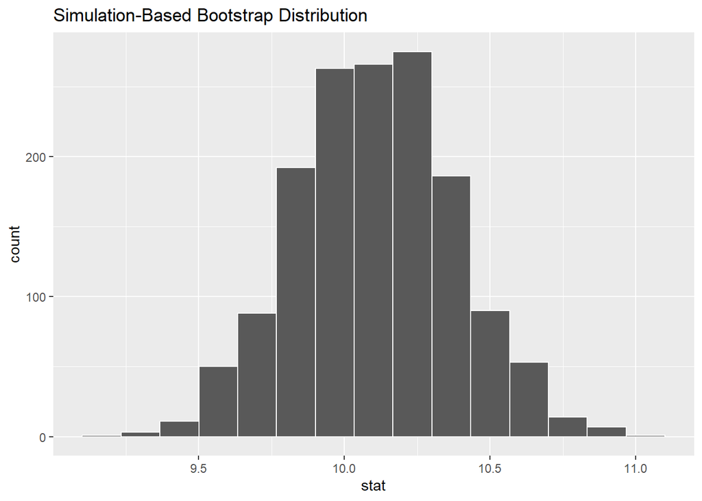

```r
boot_dist%>%visualize()
```

**Interpretation for the confidence interval**:

## 3.2 Using base R

The following code achieves the same using base R and a for loop. Ask GenAI to explain how it works and discuss it with the group. Then find a tutor, and try to explain them what you did or didn’t understand.

```r
## REMEMBER TO SET eval=TRUE

set.seed(99)
n <- nrow(jfk_flights)
B <- 1500
boot_means2 <- numeric(B)

for (i in 1:B) {
  idx <- sample(n, replace = TRUE)
  boot_means2[i] <- mean(jfk_flights$dep_delay[idx])
}

ci2_lower <- quantile(boot_means2, 0.025)
ci2_upper <- quantile(boot_means2, 0.975)

mean_dep_delay; ci2_lower; ci2_upper
```

```
## [1] 10.10761
```

```
##     2.5%
## 9.573518
```

```
##    97.5%
## 10.64339
```

## 3.3 Reflection

What was good and what was bad of GenAI’s explanation? Did you have to clarify or re-prompt? Did it match the information provided by the tutor?

It was helpful enough, instead of giving direct answer, it gave explanation and direction for thinking and acting.

# 4. Airline Delay Analysis

**Goal:** For each airline, what are the mean and median arrival delays in Jan/Feb? Which is the worst on average?

```r
## REMEMBER TO SET eval=TRUE

# Join jan_feb_flights with airlines by carrier code
jan_feb_flights <- jan_feb_flights %>%
  left_join(airlines, by = "carrier")
```

```r
# Group by airline, summarize n, mean and median arrival delay
# Arrange descending by mean delay
jan_feb_flights %>%
  group_by(carrier)%>%
  summarize(mean_arr_delay=mean(arr_delay, na.rm=TRUE),
            med_arr_delay=median(arr_delay, na.rm=TRUE),
            n_flights=n())%>%
  arrange(desc(mean_arr_delay))
```

```
## # A tibble: 16 × 4
##    carrier mean_arr_delay med_arr_delay n_flights
##    <chr>            <dbl>         <dbl>     <int>
##  1 OO             107               107         1
##  2 F9              26.0               6       108
##  3 EV              22.9               6      7998
##  4 9E               9.29             -5      3032
##  5 B6               8.38             -1      8530
##  6 YV               8.32             -5        94
##  7 MQ               7.63             -2      4315
##  8 FL               3.75             -1       624
##  9 WN               3.30             -4      1907
## 10 UA               1.76             -4      8983
## 11 AA               1.03             -7      5311
## 12 US               0.871            -5      3154
## 13 HA               0.763           -30        59
## 14 AS              -1.14             -9       118
## 15 DL              -4.56            -10      7134
## 16 VX             -14.1             -17       587
```

**Which airline(s) had the highest mean? Is there anything notable about the worst airline?**

SkyWest Airline Inc.

## 4.1 Reflection

What did GenAI help with? Was anything inaccurate, missing, or did you spot any typical “AI mistakes”? Or did you instead learn something new? Did you have to clarify or re-prompt?

# 5. GenAI Use Reflection

- Discuss with your teammates, what are the risks of using GenAI for coding? Did you use any LLM directly or you get help from IDS-sidekick ?
- What are the risks of copying code verbatim without attempting?
- Discuss the differences for someone who is just learning to code (like you) versus someone who is already proficient.
- What are your thoughts on attempting a task on your own first, and then asking GenAI for help or feedback?
- What are your thoughts on using GenAI as a *thinking partner* or *pair-programming navigator*, rather than a code-generator? Do you think IDS-sidekick is a good design based on your exploration so far?
- What is one insight or tip each of you learned today about using GenAI productively or spotting misleading AI-generated code?

Go to Learn and share your experience with us from that workshop, this information will be very useful for further iteration of IDS and use of GenAI within that module. Under Course information -> [Week4 WS GenAI Reflections](https://www.learn.ed.ac.uk/ultra/courses/_136348_1/assessment/survey/_13043810_1?gradeitemView=details)

# 6. GenAI Acknowledgment

*If you used AI for this lab, provide a statement like (make sure to specify which GenAI tool you used):*

I used ELM with IDS-sidekick for getting help for functions in infer package, also checking my codes and getting feedback.

# Wrapping Up

*Save, commit, and push your file. Remember to acknowledge any GenAI help above.*